# Term Deposit Subscription - Brandon Smith

#### Education

The level of education that the client has.

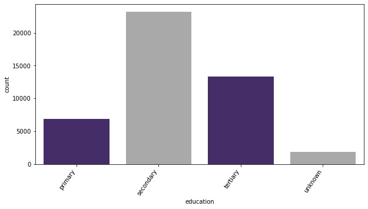

```python
#Univariate plot to look at education
plt.figure(figsize=(10,5));
chart = sns.countplot(bank_data['education'], palette=['#432371',"#A9A9A9"]);
chart.set_xticklabels(
    chart.get_xticklabels(),
    rotation=55,
    horizontalalignment='right',
    fontweight='light',
    fontsize='medium'
);

#Analysis - There are more cleints with a secondary education than others but not seeing anything to be concerned with as
#far as being skewed that needs addressed. There are some unknowns and it is not obvious which areas these would fall into
#so I am going to have to leave the unknown category at this time.
```

```python
#Get crosstab for education and Target
pd.crosstab(bank_data['education'], bank_data['Target'], normalize='index')

#Analysis - there seems to be very little difference between education and subscription.
```

| Target education | no | yes |
| --- | --- | --- |
| primary | 0.913735 | 0.086265 |
| secondary | 0.894406 | 0.105594 |
| tertiary | 0.849925 | 0.150075 |
| unknown | 0.864297 | 0.135703 |

#### Default

Does the client have credit in default.

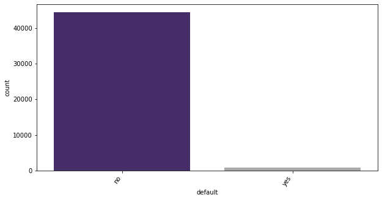

```python
#Univariate plot to look at default
plt.figure(figsize=(10,5));
chart = sns.countplot(bank_data['default'], palette=['#432371',"#A9A9A9"]);
chart.set_xticklabels(
    chart.get_xticklabels(),
    rotation=55,
    horizontalalignment='right',
    fontweight='light',
    fontsize='medium'
);

#Analysis - it looks likethe majority are not in defualt. This would be a good indicator for the bank to look
#at and avoid trying to market to these indivisuals for loans.
```

```python
#Get crosstab for default and Target
pd.crosstab(bank_data['default'], bank_data['Target'], normalize='index')

#Analysis - there seems to be very little difference between default and subscription.
```

| Target default | no | yes |
| --- | --- | --- |
| no | 0.882036 | 0.117964 |
| yes | 0.936196 | 0.063804 |

#### Housing

Does the client have loan for housing.

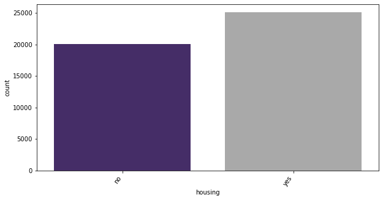

```python
#Univariate plot to look at housing
plt.figure(figsize=(10,5));
chart = sns.countplot(bank_data['housing'], palette=['#432371',"#A9A9A9"]);
chart.set_xticklabels(
    chart.get_xticklabels(),
    rotation=55,
    horizontalalignment='right',
    fontweight='light',
    fontsize='medium'
);

#Analysis - It looks like this data is close and we should not need to worry about.
```

```python
#Get crosstab for housing and Target
pd.crosstab(bank_data['housing'], bank_data['Target'], normalize='index')

#Analysis - there seems to be very little difference between housing and subscription.
```

| Target housing | no | yes |
| --- | --- | --- |
| no | 0.832976 | 0.167024 |
| yes | 0.922997 | 0.077003 |

#### Loan

Does the client have a personal loan.

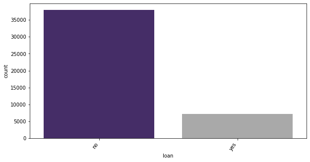

```python
#Univariate plot to look at loan
plt.figure(figsize=(10,5));
chart = sns.countplot(bank_data['loan'], palette=['#432371',"#A9A9A9"]);
chart.set_xticklabels(
    chart.get_xticklabels(),
    rotation=55,
    horizontalalignment='right',
    fontweight='light',
    fontsize='medium'
);

#Analysis - It does look like there are some clients 1/5 to 1/7 of them that have a personal loan.
```

```python
#Get crosstab for loan and Target
pd.crosstab(bank_data['loan'], bank_data['Target'], normalize='index')

#Analysis - there seems to be very little difference between loan and subscription.
```

| Target loan | no | yes |
| --- | --- | --- |
| no | 0.873439 | 0.126561 |
| yes | 0.933186 | 0.066814 |

#### Balance

Balance in the clients account.

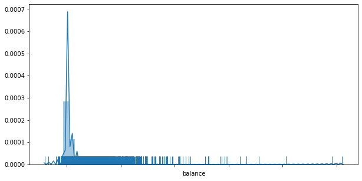

```python
#Univariate plot to look at balance- tried to evaluate this in a countplot and was way too big and overwhelming. I
#went with a distplot to give me a high level view.
plt.figure(figsize=(10,5));
chart = sns.distplot(bank_data['balance'],kde=True, rug=True);
chart.set_xticklabels(
    chart.get_xticklabels(),
    rotation=55,
    horizontalalignment='right',
    fontweight='light',
    fontsize='medium'
);

#Analysis - The data is skewed and there are some random outliers
#that are gradual. Due to them being gradual I am not going to drop any of them and rely on the standard scaler.
```

```python
#Get a better view of the balances over the 50k mark to see if gradual increase or major outliers
high_balance_data = bank_data[bank_data['balance'] > 50000]
display(high_balance_data)

#Analysis - The balances go up gradual in the 50's, 60's, 70's, 80's, 90's and top out at the 102k.
```

|  | age | job | marital | education | default | balance | housing | loan | contact | day | month | duration | campaign | pdays | previous | poutcome | Target |
| --- | --- | --- | --- | --- | --- | --- | --- | --- | --- | --- | --- | --- | --- | --- | --- | --- | --- |
| 920 | 44 | admin. | married | secondary | no | 58544 | yes | no | unknown | 7 | may | 144 | 2 | -1 | 0 | unknown | no |
| 3197 | 43 | admin. | single | secondary | no | 56831 | no | no | unknown | 15 | may | 243 | 1 | -1 | 0 | unknown | no |
| 9536 | 58 | entrepreneur | married | primary | no | 52499 | no | no | unknown | 6 | jun | 198 | 2 | -1 | 0 | unknown | no |
| 12926 | 56 | blue-collar | married | secondary | no | 58932 | no | no | telephone | 7 | jul | 339 | 2 | -1 | 0 | unknown | no |
| 13154 | 56 | entrepreneur | married | tertiary | no | 51439 | no | yes | cellular | 8 | jul | 325 | 1 | -1 | 0 | unknown | no |
| 19420 | 59 | admin. | married | unknown | no | 64343 | no | no | cellular | 6 | aug | 45 | 4 | -1 | 0 | unknown | no |
| 19785 | 56 | management | divorced | tertiary | no | 66721 | no | no | cellular | 8 | aug | 442 | 2 | -1 | 0 | unknown | no |
| 21192 | 52 | blue-collar | married | primary | no | 66653 | no | no | cellular | 14 | aug | 109 | 3 | -1 | 0 | unknown | no |
| 22091 | 40 | management | married | tertiary | no | 52527 | no | no | cellular | 21 | aug | 140 | 11 | -1 | 0 | unknown | no |
| 26227 | 59 | management | married | tertiary | no | 98417 | no | no | telephone | 20 | nov | 145 | 5 | -1 | 0 | unknown | no |
| 27390 | 50 | services | married | secondary | no | 57435 | yes | no | cellular | 21 | nov | 319 | 3 | -1 | 0 | unknown | no |
| 39989 | 51 | management | single | tertiary | no | 102127 | no | no | cellular | 3 | jun | 90 | 1 | -1 | 0 | unknown | no |
| 40763 | 61 | self-employed | divorced | tertiary | no | 52587 | no | no | cellular | 10 | aug | 290 | 1 | -1 | 0 | unknown | yes |
| 41374 | 32 | entrepreneur | single | tertiary | no | 59649 | no | no | cellular | 1 | sep | 69 | 2 | -1 | 0 | unknown | no |
| 41693 | 60 | retired | married | primary | no | 71188 | no | no | cellular | 6 | oct | 205 | 1 | -1 | 0 | unknown | no |
| 42558 | 84 | retired | married | secondary | no | 81204 | no | no | telephone | 28 | dec | 679 | 1 | 313 | 2 | other | yes |
| 43053 | 61 | self-employed | divorced | tertiary | no | 52587 | no | no | cellular | 15 | feb | 394 | 3 | 189 | 1 | success | yes |
| 43393 | 84 | retired | married | secondary | no | 81204 | no | no | telephone | 1 | apr | 390 | 1 | 94 | 3 | success | yes |

#### Contact

Contact communication type.

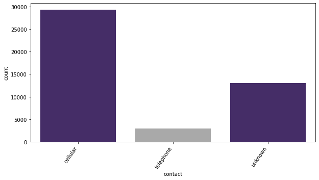

```python
#Look at the data for the cummunication type.
plt.figure(figsize=(10,5));
chart = sns.countplot(bank_data['contact'], palette=['#432371',"#A9A9A9"]);
chart.set_xticklabels(
    chart.get_xticklabels(),
    rotation=55,
    horizontalalignment='right',
    fontweight='light',
    fontsize='medium'
);

#Analysis - There are a fair amount of unknowns but I am not able to
#effectively predict the communication type so I am going to have to leave the unknown category at this time.
```

```python
#Get crosstab for contact and Target
pd.crosstab(bank_data['contact'], bank_data['Target'], normalize='index')

#Analysis - there seems to be a little difference between contact and subscription. The cellular and telephone
#are higher than the unknown.
```

| Target contact | no | yes |
| --- | --- | --- |
| cellular | 0.850806 | 0.149194 |
| telephone | 0.865795 | 0.134205 |
| unknown | 0.959293 | 0.040707 |

#### Month

The last contact month of the year.

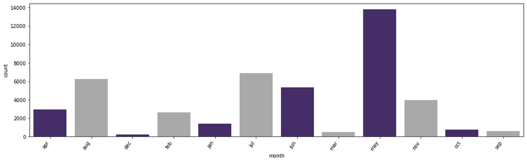

```python
#Evaluate the data for the month of the year that the client was last contacted in.
plt.figure(figsize=(18,5));
chart = sns.countplot(bank_data['month'], palette=['#432371',"#A9A9A9"]);
chart.set_xticklabels(
    chart.get_xticklabels(),
    rotation=55,
    horizontalalignment='right',
    fontweight='light',
    fontsize='medium'
);

#Analysis - It looks like according to the data, the middle of the year to the third quarter was the peak for
#when the clients were last contacted. The end of the year and first part of the year were the least amounts of
#contacts.
```

#### Day

Last contact day of the month.

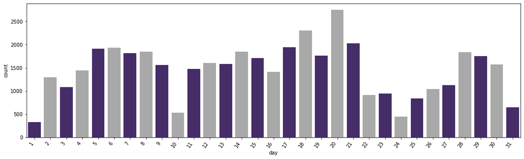

```python
#Evaluate the day of the month for the last contact to the client.
plt.figure(figsize=(18,5));
chart = sns.countplot(bank_data['day'], palette=['#432371',"#A9A9A9"]);
chart.set_xticklabels(
    chart.get_xticklabels(),
    rotation=55,
    horizontalalignment='right',
    fontweight='light',
    fontsize='medium'
);

#Analysis - It is pretty even throughout the month with it being a little light on the first and last day
#of the month besides a few random days in between. The few random days are exactly two weeks apart so
#one could speculate that this was maybe on a sunday when there were less people working and banks are typically
#closed.
```

#### Duration

Tha last contact duration (seconds).

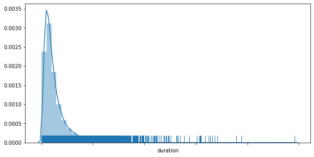

```python
#Evaluate the duration of the contact. This was a lot of varying data so went with a high level view on
#a distplot to start.
plt.figure(figsize=(10,5));
chart = sns.distplot(bank_data['duration'],kde=True, rug=True);
chart.set_xticklabels(
    chart.get_xticklabels(),
    rotation=55,
    horizontalalignment='right',
    fontweight='light',
    fontsize='medium'
);

#Analysis - This distplot is expected by seeing the 258 mean in the description above. With the 25% at 103, 50% at 180 and
#75% at 319. There are some longer outliers. Will need to see if there are any that are far out there alone and can or should
#be removed from the dataset.
```

```python
#Evaluate duration data that is greater than 3000
high_duration_data = bank_data[bank_data['duration'] > 3000]
display(high_duration_data)
```

|  | age | job | marital | education | default | balance | housing | loan | contact | day | month | duration | campaign | pdays | previous | poutcome | Target |
| --- | --- | --- | --- | --- | --- | --- | --- | --- | --- | --- | --- | --- | --- | --- | --- | --- | --- |
| 2386 | 45 | blue-collar | married | secondary | no | 66 | yes | no | unknown | 13 | may | 3366 | 3 | -1 | 0 | unknown | no |
| 4382 | 34 | blue-collar | married | primary | no | 183 | yes | no | unknown | 19 | may | 3078 | 4 | -1 | 0 | unknown | no |
| 6451 | 44 | services | divorced | secondary | no | 51 | yes | yes | unknown | 27 | may | 3094 | 2 | -1 | 0 | unknown | yes |
| 9947 | 59 | management | married | secondary | no | 1321 | no | no | unknown | 9 | jun | 3881 | 3 | -1 | 0 | unknown | yes |
| 12347 | 28 | admin. | single | secondary | no | -7 | no | yes | unknown | 26 | jun | 3183 | 2 | -1 | 0 | unknown | yes |
| 19639 | 37 | blue-collar | married | tertiary | no | 359 | no | yes | cellular | 7 | aug | 3422 | 2 | -1 | 0 | unknown | no |
| 21113 | 43 | self-employed | married | tertiary | no | 423 | no | no | cellular | 14 | aug | 3322 | 2 | -1 | 0 | unknown | no |
| 24044 | 36 | self-employed | single | tertiary | no | -103 | yes | yes | telephone | 17 | oct | 3253 | 1 | -1 | 0 | unknown | yes |
| 24095 | 30 | admin. | married | secondary | no | 1310 | no | no | telephone | 27 | oct | 3284 | 1 | -1 | 0 | unknown | no |
| 24148 | 59 | technician | married | tertiary | no | 6573 | yes | no | telephone | 10 | nov | 4918 | 1 | -1 | 0 | unknown | no |
| 28872 | 59 | unemployed | married | primary | no | 0 | no | no | cellular | 30 | jan | 3025 | 2 | -1 | 0 | unknown | no |
| 30747 | 53 | admin. | married | secondary | no | 849 | yes | no | cellular | 6 | feb | 3102 | 3 | -1 | 0 | unknown | yes |
| 31337 | 47 | blue-collar | married | secondary | no | 238 | yes | yes | cellular | 13 | mar | 3076 | 1 | -1 | 0 | unknown | yes |
| 44602 | 45 | services | single | secondary | no | 955 | no | no | unknown | 27 | aug | 3785 | 1 | -1 | 0 | unknown | no |

#### Campaign

Number of contacts performed during this campaign and for this client.

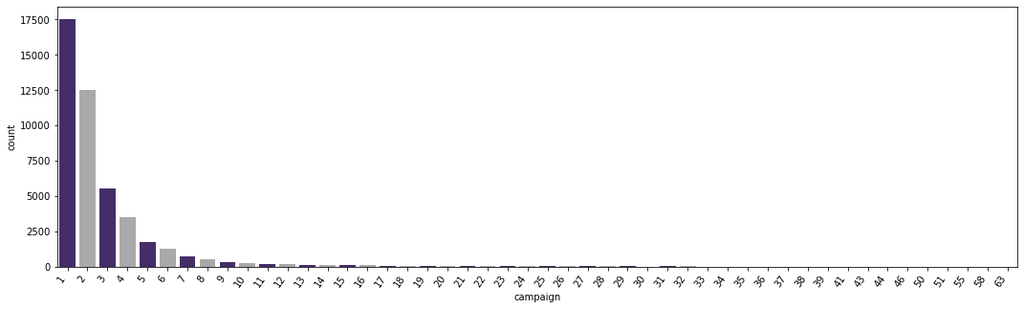

```python
# Campagin analysis to find the number of contacts performed during this campaign for this client
plt.figure(figsize=(18,5));
chart = sns.countplot(bank_data['campaign'], palette=['#432371',"#A9A9A9"]);
chart.set_xticklabels(
    chart.get_xticklabels(),
    rotation=55,
    horizontalalignment='right',
    fontweight='light',
    fontsize='medium'
);

#Analysis - It looks like the data here is highly skewed and that there were only one to seven contacts
#made to the client over this campaign with the highest count being only one contact. At some point, marketing
#should also keep an eye and have a limit on the number of contacts per a client. While they want to try
#and get clients to expand their services, they should be cognitive of the number of contacts. Most clients would not
#want to be contacts as many as some of them have here as they could get frustrated and leave the bank all together
#and this would create anegative result from trying to grow the bank and the profits.
```

```python
#Look into the actual count and results for clients contacted over 12 times
high_campaign_data = bank_data[bank_data['campaign'] > 12]
display(high_campaign_data)
```

|  | age | job | marital | education | default | balance | housing | loan | contact | day | month | duration | campaign | pdays | previous | poutcome | Target |
| --- | --- | --- | --- | --- | --- | --- | --- | --- | --- | --- | --- | --- | --- | --- | --- | --- | --- |
| 2626 | 31 | technician | married | secondary | no | 106 | yes | no | unknown | 13 | may | 101 | 13 | -1 | 0 | unknown | no |
| 2706 | 46 | admin. | divorced | tertiary | no | 3749 | yes | no | unknown | 13 | may | 69 | 19 | -1 | 0 | unknown | no |
| 2967 | 37 | technician | married | tertiary | yes | 0 | yes | no | unknown | 14 | may | 93 | 14 | -1 | 0 | unknown | no |
| 3044 | 51 | unemployed | married | secondary | no | 425 | yes | no | unknown | 14 | may | 286 | 14 | -1 | 0 | unknown | no |
| 3079 | 28 | blue-collar | married | primary | no | 0 | no | no | unknown | 14 | may | 17 | 24 | -1 | 0 | unknown | no |
| ... | ... | ... | ... | ... | ... | ... | ... | ... | ... | ... | ... | ... | ... | ... | ... | ... | ... |
| 38767 | 28 | admin. | married | secondary | no | 788 | yes | no | cellular | 18 | may | 11 | 14 | -1 | 0 | unknown | no |
| 40336 | 57 | entrepreneur | married | tertiary | no | 0 | no | no | telephone | 18 | jun | 390 | 15 | -1 | 0 | unknown | no |
| 41380 | 43 | unemployed | married | unknown | no | 970 | yes | no | telephone | 1 | sep | 513 | 13 | 288 | 11 | failure | no |
| 42315 | 62 | technician | married | secondary | no | 135 | yes | no | telephone | 16 | nov | 446 | 13 | 96 | 1 | other | no |
| 44594 | 34 | technician | single | tertiary | no | 2481 | no | no | cellular | 23 | aug | 220 | 16 | 192 | 14 | other | no |

840 rows × 17 columns

```python
#campaign count based on target (if the client subscribed term deposit)
bank_data.groupby(['Target'])['campaign'].value_counts()

#Analysis - i would be intregiued to find out if the clients that got contacted through campaign that
#number of times were subscribed already. Is there a marketing issue where they are marketing to existing
#subscribers or did someone finally give in after being contacted 63 times. If it took 63 times
#i would be more intriged to look at the data for the number of clients that where contacted (campaign
#count) and the number of them that closed accounts.
```

```
Target  campaign
no      1           14983
        2           11103
        3            4903
        4            3205
        5            1625
                    ...
yes     20              1
        21              1
        24              1
        29              1
        32              1
Name: campaign, Length: 70, dtype: int64
```